# lab2

Avigal & Yosef

1 6 2020

Show numbers in plots/tables using standard digits and not scientific display. That is: 90000000 and not 9e+06.  
Round numbers to at most 3 digits after the dot - that is, 9.456 and not 9.45581451044

The required libraries are listed below the instructions. You are allowed to add additional libraries if you want. If you do so, *please explain what libraries you’ve added, and what is each new library used for*.

#### Background:

You’ve been hired as a data analyst at the football (soccer) club Hapoel London. Since this is a small and under-funded club, you will not have access to real-football data, but to data from the football computer game fifa18. Your job is to analyze this dataset and extract meaningful insights from the data in order to help your club make better decisions.

#### Data File:

You will load and analyze the fifa18 football dataset file called “fifa_data.csv”.  
The dataset contains detailed information about each player in the game, including: names, age, nationality, overall ability, estimated potential ability, current club and league, market value, salary (wage), ability at different football skills (also called ‘attributes’, e.g. Ball.control, Sprint.speed …), ability to play at different position in the game (CF, CM, …) and the preferred positions of the player.

Required Libraries:

```
## ### Welcome to rworldmap ###
```

```
## For a short introduction type :   vignette('rworldmap')
```

## Q1. Basic Statistics (25 pt)

First, you are requested to load the fifa18 dataset and find and display general information about the players.

1. Make a plot showing the age distribution of all players.
2. Make a plot comparing the *overall* ability of players in different leagues (‘League’). Describe which leagues have especially good/bad players.
3. Make a plot showing the density of players’ salary (‘Wage’) distribution.  
   Next, make a separate plot showing the density distribution of the *log* of players’ salary.  
   Which of the two visualizations is better? how skewed are the distributions? do they have fat tails? which is better described by a Normal distribution? explain.
4. Are the top-10 players with the highest value also the top-10 best players in terms of *overall* ability? Show tables for both and compare.  
   Who is the best player not in the top-10 valued players?
5. Show a table of the ten *best* and ten *worst* teams in terms of *average* player overall ability.

Loading the data:

```r
fifa_players <- data.frame(read.csv(url("https://raw.githubusercontent.com/DataScienceHU/DataAnalysisR_2020/master/data/fifa_data.csv")))

# Pre-processing:
for (i in c(3,6,7,10:71)) {
  fifa_players[,i]<-as.numeric((fifa_players[,i]))
}
fifa<-na.omit(fifa_players)
fifa_players<-fifa
fifa_players_info<-fifa[,c(1:11)] # players general info
fifa_players_attribures<-fifa[,c(1,12:45, 6)] # players different skills. Add overall
fifa_players_positions<-fifa[,c(1,46:72,6)] # players ability at different positions . Add overall
```

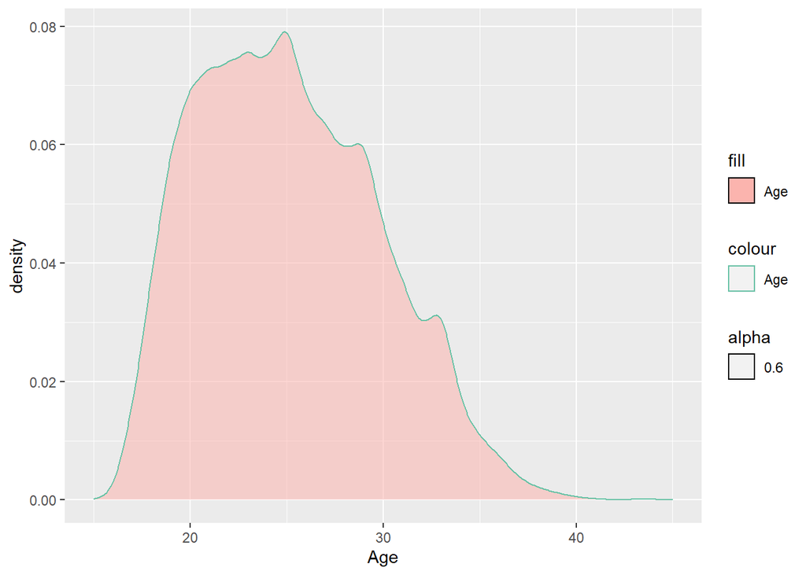

```r
#A
ggplot(fifa_players, aes(x=Age,color="Age", fill="Age", alpha=0.6)) + geom_density() + xlim(15,45) + scale_fill_brewer(palette = "Pastel1") + scale_color_brewer( palette = "Set2")
```

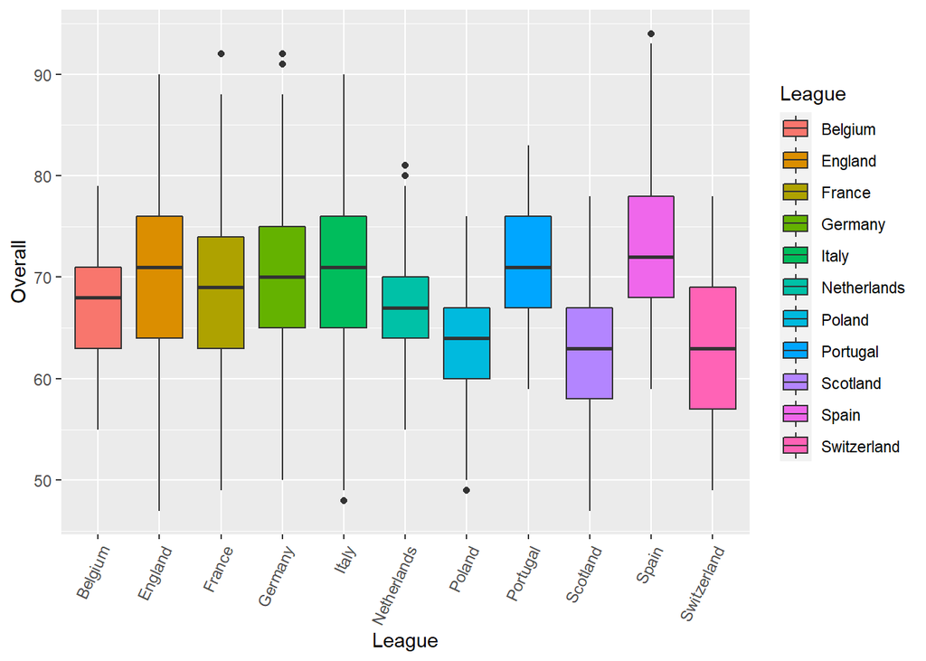

```r
#B
#data frame of the overall average by League
#fixing the leagues name to shorter names
fifa_players$League <- as.character(fifa_players$League)
fifa_players$League[fifa_players$League == "Spain LIGA BBVA in last 15 years"] <- "Spain"
fifa_players$League[fifa_players$League == "Portugal Liga ZON Sagres in last 15 years"] <- "Portugal"
fifa_players$League[fifa_players$League == "Italy Serie A in last 15 years"] <- "Italy"
fifa_players$League[fifa_players$League == "England Premier League in last 15 years"] <- "England"
fifa_players$League[fifa_players$League == "Germany 1. Bundesliga in last 15 years"] <- "Germany"
fifa_players$League[fifa_players$League == "France Ligue 1 in last 15 years"] <- "France"
fifa_players$League[fifa_players$League == "Netherlands Eredivisie in last 15 years"] <- "Netherlands"
fifa_players$League[fifa_players$League == "Belgium Jupiler League in last 15 years"] <- "Belgium"
fifa_players$League[fifa_players$League == "Poland Ekstraklasa in last 15 years"] <- "Poland"
fifa_players$League[fifa_players$League == "Switzerland Super League in last 15 years"] <- "Switzerland"
fifa_players$League[fifa_players$League == "Scotland Premier League in last 15 years"] <- "Scotland"

#creating a new dataframe so i can drop the "other" league because it isn't a real league so we don't want to show it in the boxplot.
overall_league <- data.frame(League = fifa_players$League, Overall = fifa_players$Overall)
overall_league <- overall_league[-which(overall_league$League == "other"),]


ggplot(overall_league, aes(x=League, y=Overall, fill= League)) +
  geom_boxplot() +
  theme(axis.text.x = element_text(angle = 65, hjust = 1))
```

```r
  theme(legend.position="none")
```

```
## List of 1
##  $ legend.position: chr "none"
##  - attr(*, "class")= chr [1:2] "theme" "gg"
##  - attr(*, "complete")= logi FALSE
##  - attr(*, "validate")= logi TRUE
```

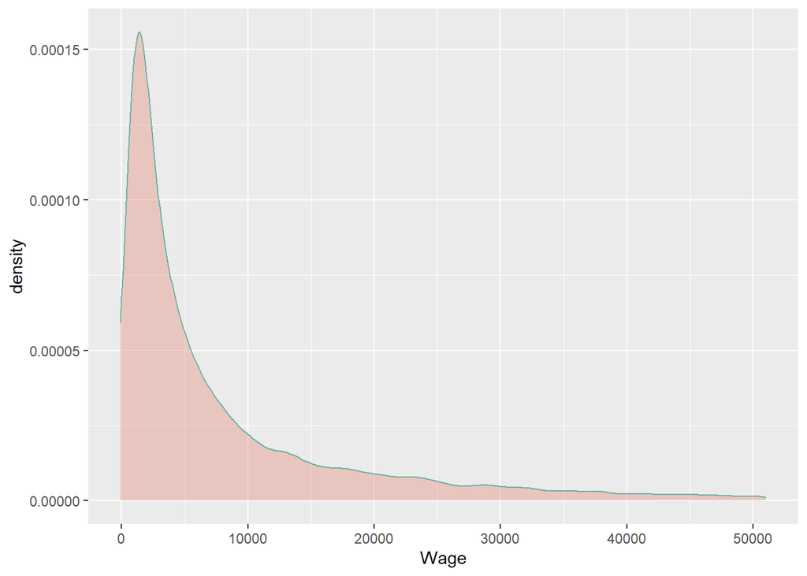

```r
#C_1
ggplot(fifa_players, aes(x=Wage)) + geom_density(color="#69b3a2", fill="#e68c7c", alpha=0.4) + xlim(-100,51000)
```

#here we’ve got a really long tail. It’s clearly doeasn’t look like a normal distribiution

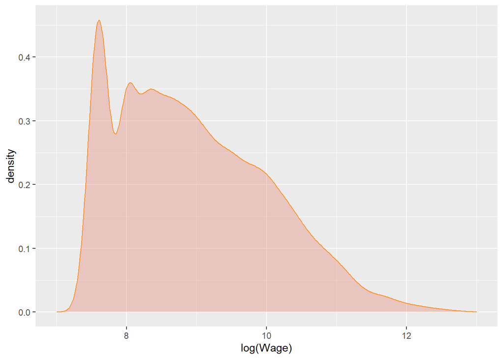

```r
#C_2
ggplot(fifa_players, aes(x=log(Wage))) + geom_density(color="#fd8f24", fill="#e68c7c", alpha=0.4) + xlim(7,13)
```

#here we clearly have much more normal distribiution.

```r
#D
top_10_overall <- order(fifa_players$Overall, decreasing = TRUE)[c(1:10)]
top_10_overall
```

```
##  [1] 16518 16315  1869  2318 16316  2319   648   890  3141 16519
```

```r
top_10_wage <- order(fifa_players$Wage, decreasing = TRUE)[c(1:10)]
top_10_wage %in% top_10_overall
```

```
##  [1]  TRUE  TRUE  TRUE FALSE  TRUE  TRUE FALSE FALSE FALSE  TRUE
```

#it means that not in every one we have a correlation, and that means that there is people who are vert talented but doesn’t get the money they deserve.

```r
#E
teams <- fifa_players%>%
  group_by(Club)%>%
    summarise(ability = mean(Overall))
top_10_team <- order(teams$ability, decreasing = TRUE)[c(1:10)]
top_10_team
```

```
##  [1] 226 339 472 229 437 405 384 483 522 330
```

```r
so_low_team <- order(teams$ability, decreasing = FALSE)[c(10:1)]
so_low_team
```

```
##  [1] 198 234 181 104 538  94 372 267 203 282
```

```r
teams[c(top_10_team, so_low_team),]
```

```
## # A tibble: 20 x 2
##    Club                ability
##    <fct>                 <dbl>
##  1 FC Barcelona           82.6
##  2 Juventus               81.5
##  3 Real Madrid CF         81.0
##  4 FC Bayern Munich       80.2
##  5 Paris Saint-Germain    78.0
##  6 Napoli                 77.6
##  7 Manchester United      77.5
##  8 Roma                   77.0
##  9 Sevilla FC             77.0
## 10 Inter                  76.7
## 11 Derry City             56.8
## 12 FC HelsingÃ¸r          56.6
## 13 Crewe Alexandra        56.3
## 14 Bray Wanderers         56.2
## 15 Sligo Rovers           56.1
## 16 Bohemian FC            55.8
## 17 Limerick FC            55.5
## 18 Finn Harps             55
## 19 Drogheda United        54.8
## 20 Galway United          54.1
```

```r
#here we've got the 10 best scorred and ten worst scorred team. We combined them into one table.
```

## Q2. Scouting Report (25 pt)

You are in charge of the scouting division. The goal of this division is to follow players’ potential and overall ability, and identify undervalued players - that is, players whose current value is lower compared to what would be expected based on their predicted future ability.

1. Your boss wants to fly abroad to recruit promising players. Use the *rworldmap* package to display the world map and color each country based on the *total number of players* from this nationality.
2. Quantity may not guarantee quality. Repeat the above analysis but this time display a world map where each country is colored by the *average overall quality* of players. Find an under-represented country you’d recommend to travel to (i.e. a country with few players with high overall average quality).
3. Show the *average overall* ability by *age* of all players, for players 35 years old or younger
4. Make a graph showing the *average difference* between a player’s overall ability to potential ability as a function of age, up to age 35. At what ages should we expect to find players for future development based on this graph?
5. We are seeking young (age <=21) players with high Overall ability (>70). Show a scatter plot of these players comparing their *Potential* ability (y-axis) and current salary (*Wage*, x-axis). Prepare a table showing the 10 most-undervalued players, i.e. currently lowest payed compared to their potential. Calculate for each of them what is a fair salary matching their potential that you would offer to lure them away from their current club and show it in the table.

```r
#A
fifa$freq<-1
freq_players<-aggregate(freq ~ Nationality ,data = fifa ,FUN = sum)
freq_players$Nationality = as.character(freq_players$Nationality)
freq_players[c(37,107,135),1] <- "United Kingdom"   # replace Englend,Wales,Scotland as United Kingdom
freq_players[102,1]<- "Ireland"                     # replace Republic of Ireland as Ireland
x<-joinCountryData2Map(freq_players , joinCode = 'NAME', nameJoinColumn = "Nationality" )
```

```
## 137 codes from your data successfully matched countries in the map
## 0 codes from your data failed to match with a country code in the map
## 108 codes from the map weren't represented in your data
```

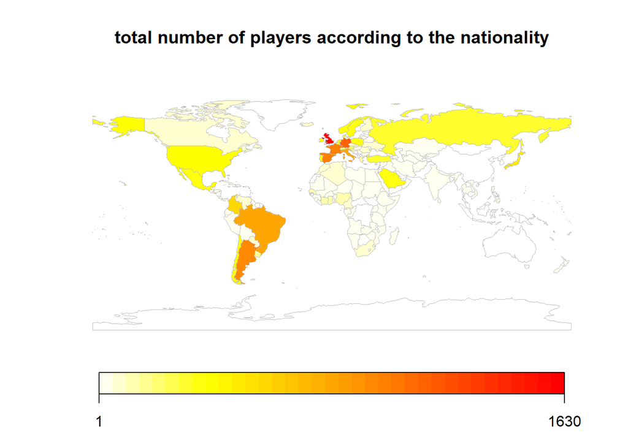

```r
mapCountryData(x, catMethod ="fixedwidth",nameColumnToPlot = "freq" ,mapTitle="total number of players according to the nationality",numCats=35 )
```

#we add a column of 1 and did aggrigate and showed on a map of the world

```r
#B
Overall_mean<-aggregate(Overall ~ Nationality ,data = fifa ,FUN = mean)
Overall_mean$Nationality= as.character(Overall_mean$Nationality)
Overall_mean[c(37,107,135),1] <- "United Kingdom"   # replace Englend,Wales,Scotland as United Kingdom
Overall_mean[102,1]<- "Ireland"                     # replace Republic of Ireland as Ireland
y<-joinCountryData2Map( Overall_mean, joinCode = 'NAME', nameJoinColumn = "Nationality")
```

```
## 137 codes from your data successfully matched countries in the map
## 0 codes from your data failed to match with a country code in the map
## 108 codes from the map weren't represented in your data
```

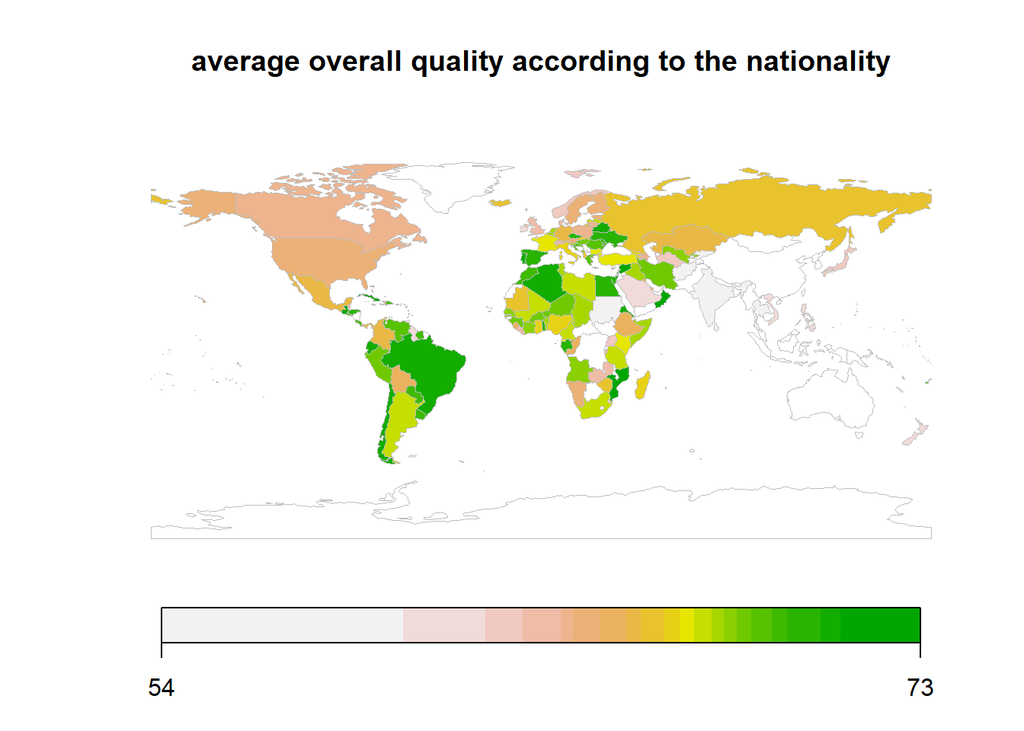

```r
mapCountryData(y ,nameColumnToPlot = "Overall" ,mapTitle="average overall quality according to the nationality"
  , colourPalette="terrain" ,numCats=20)
```

# country i would recommend to travel to is *oman* only 1 player and high overall average quality 73

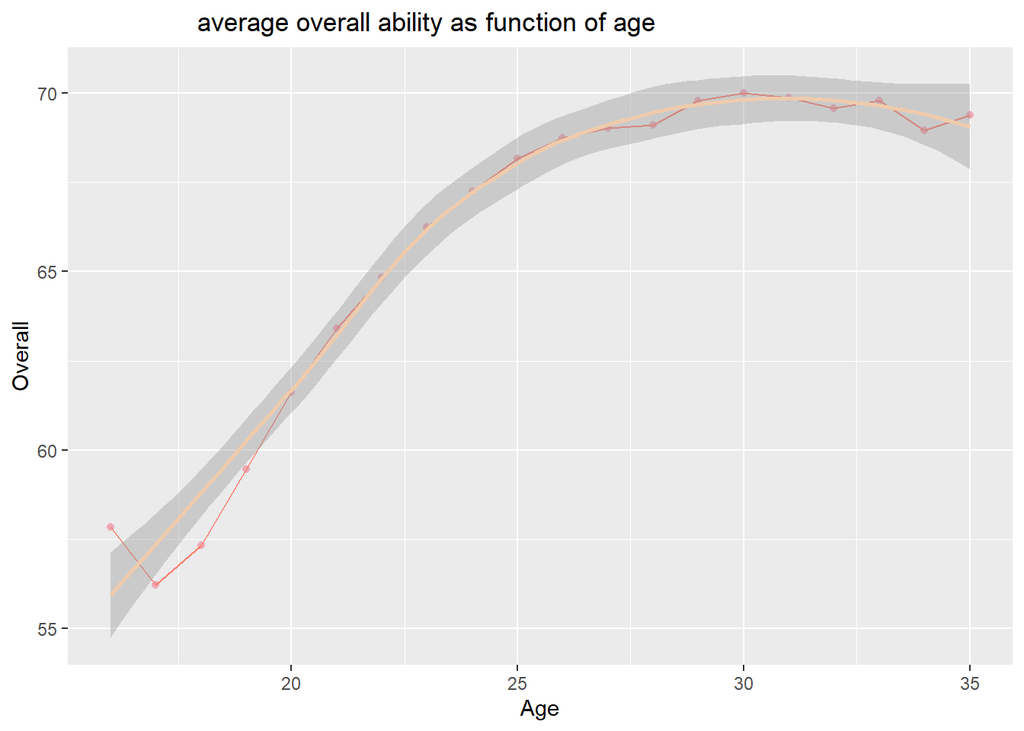

```r
#C
Overall_Ability <- aggregate(Overall~Age, data = fifa, FUN = mean)
Overall_until_35<- head(Overall_Ability,20)
ggplot(Overall_until_35,aes(x = Age, y = Overall)) +
ggtitle('                 average overall ability as function of age')+
geom_point(colour = "pink2")+
geom_line(colour = 'salmon')+
geom_smooth(colour = 'peachpuff2')
```

#we did aggregate for mean overall ability until (and including) age 35. #we added to lines. one that indicates the accurate values and a smoother one that pointing to an upward trend.

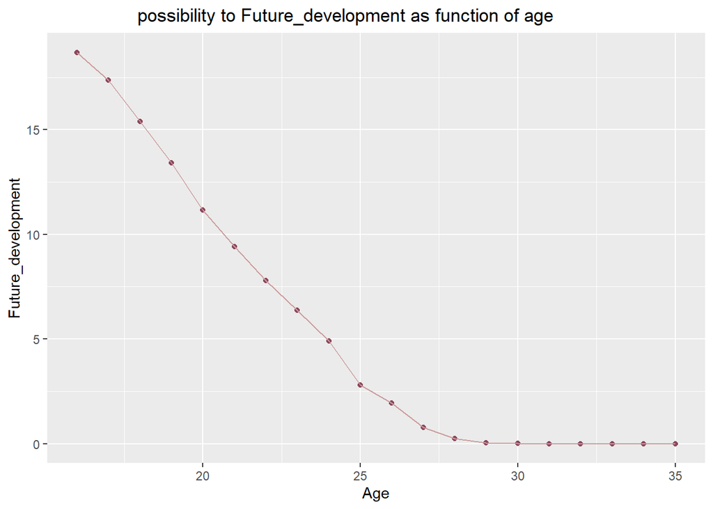

```r
#D
Potential_Ability <- aggregate(Potential~Age, data = fifa, FUN = mean)
Potential_until_35 <-head(Potential_Ability,20)
difference<-data.frame(Future_development=Potential_until_35$Potential-Overall_until_35$Overall
,Age = Potential_until_35$Age)
ggplot(difference,aes(x = Age,y =Future_development))+
ggtitle('                 possibility to Future_development as function of age')+
geom_point(colour ="palevioletred4")+
geom_line(colour ="rosybrown3")
```

# we can see that over the time the hope for future development is decreasing therefor it’s worth and we need to find younger players the best is at age 16 but you can until let sey age 25

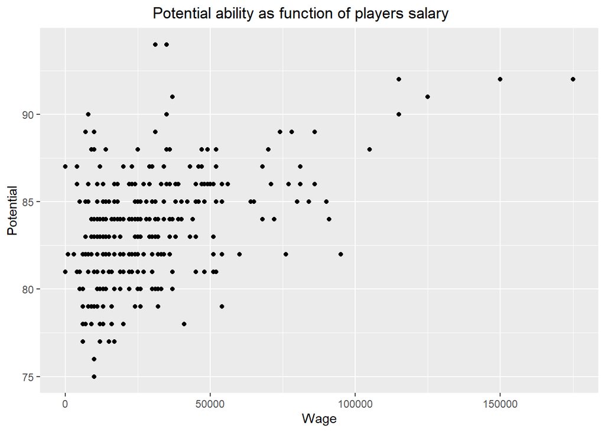

```r
#E
fifa_select <- fifa %>% select(Name,Age,Overall,Potential,Wage)
Young_players<-fifa_select[fifa_select$Overall>70 & fifa_select$Age<=21,]
ggplot(Young_players,aes(x = Wage,y = Potential)) +
ggtitle('                         Potential ability as function of players salary')+
geom_point()
```

```r
Young_players$p_divide_w <- Young_players$Potential / Young_players$Wage
Young_players<-Young_players[order(Young_players$p_divide_w, decreasing = TRUE),]
the_10_under_value<-head(Young_players,10)
print(the_10_under_value)
```

```
##               Name Age Overall Potential Wage p_divide_w
## 15793 W. FarÃÃ±ez  19      73        87    0        Inf
## 15814   R. Coetzee  20      71        81    0        Inf
## 13603 V. Kovalenko  21      74        82 1000 0.08200000
## 7285    J. Barrera  21      72        82 3000 0.02733333
## 8216       AleÃ±Ã   19      71        87 4000 0.02175000
## 8214       Vitinho  19      71        86 4000 0.02150000
## 16143  G. TroupÃ©e  19      71        81 4000 0.02025000
## 17327 Jorge SÃ¡enz  20      71        85 5000 0.01700000
## 17623       CotÃ¡n  21      72        81 5000 0.01620000
## 8275     K. Acosta  21      72        80 5000 0.01600000
```

```r
fair_wage<-aggregate(Wage~Potential, data = Young_players, FUN = mean)
Suitable_wage<-full_join(the_10_under_value,fair_wage,by = "Potential",)
Suitable_wage<-na.omit(Suitable_wage)
fair_wage_table<-data.frame(Name = Suitable_wage$Name,fair_salary =Suitable_wage$Wage.y)
print(fair_wage_table)
```

```
##            Name fair_salary
## 1  W. FarÃÃ±ez    35466.67
## 2    R. Coetzee    22571.43
## 3  V. Kovalenko    25055.56
## 4    J. Barrera    25055.56
## 5       AleÃ±Ã     35466.67
## 6       Vitinho    38375.00
## 7   G. TroupÃ©e    22571.43
## 8  Jorge SÃ¡enz    35631.58
## 9        CotÃ¡n    22571.43
## 10    K. Acosta    20476.19
```

#we want the results up to 70, and till age 21. we defined a list of the ten’th least valued players that we will want to make an offer (more attractive then the one they’ve gor now) for them. #we want that each player will get the avarage that other players at the same levele gets. we created a fair wage (in our eyes of course..)

## Q3. Model Building (30 pt)

In this question we try to find specific skills which can *predict* the overall players’ quality. We will also build graphs which will help us compare different skills.

1. We are interested in finding out which skills are similar in terms of players’ performance at the position. Extract the 29 skills for non-goalkeeper players (Acceleration, …, Volleys, except ’GK.*’ skills). Calculate the correlation between players’ ability in each pair of skills and show a heatmap correlation-plot of the correlations’ matrix. What two skills seem least correlated with other skills?
2. Consider the following six major players positions: CAM, CB, CM, RB, RW, ST and in addition the Overall players’ performance. Show a correlation-plot of players’ skill levels vs. their performance at the six positions + Overall performance. Find the 7 skills mostly correlated for player’s Overall performance and list them in a table.
3. Build your team by selecting six *different* players, one in each of the above positions in such a way that the players chosen are the best in their individual position. If the same player is the best at multiple positions, try to build the team in such a way that maximize the team’s overall average score. Using the function `radarchart::chartJSRadar`,graph their abilities (individually for all 6 player) in a spider (radarchart) graph. See below an example for such a chart. What is your team’s overall average score? [radar chart](https://en.wikipedia.org/wiki/Radar_chart) (also called ‘spider chart’)
4. We are interested in determining how each of the different player’s abilities changes with age. Repeat the analysis of question 2.c., but this time show the different skills separately. Which skills peak at youngest/oldest ages?
5. Your boss suggests that some players may be currently under-performing compared to their skill levels (possibly due to poor fit with their current Club, recent injuries, bad luck, psychological or other reasons), and that acquiring them may be beneficial as they will be expected to perform better in the future. Fit a multiple regression model predicting player’s Overall performance based on their skill level at the 29 different skills. Find the $10$ players with the least Overall performance level compared to what would their set of skills predict, and list them in a table.

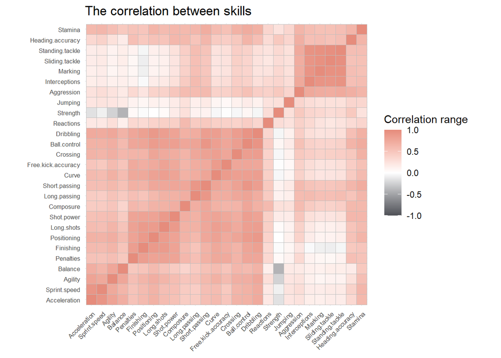

```r
#A
library(ggcorrplot)
cor_data <- fifa_players[c(1,2,3,12:22,28:45)] #creating a new dataframe for checking the correlation
cor_skills <- cor(cor_data[4:30], cor_data[4:30])

ggcorrplot(cor_skills, legend.title = "Correlation range", title = "The correlation between skills", hc.order = TRUE, tl.cex=6.5, colors = c("#4f5157", "white","#e68c7c"))
```

#in the corplot we can see clearly that the 2 least correlated skills are Jumping ans Strength.

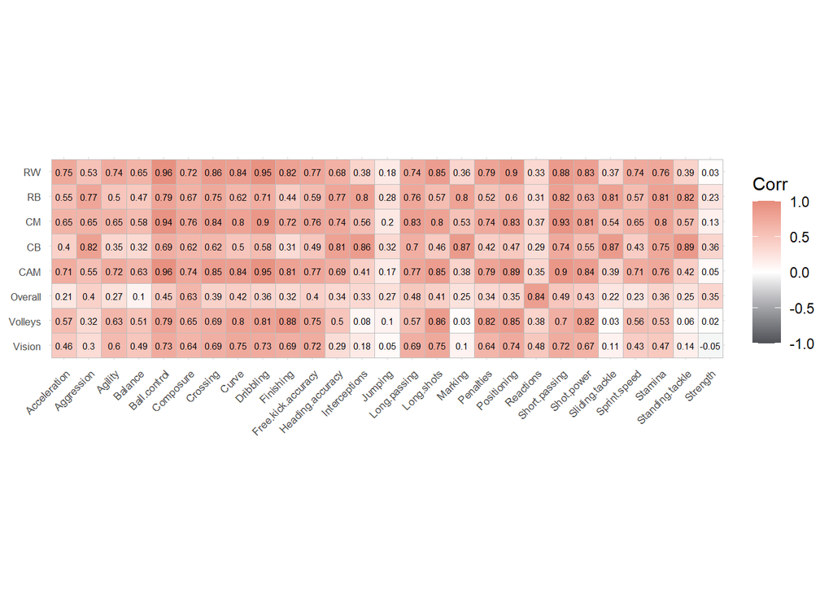

```r
#B
players_rule <- fifa_players[c(1,2,12:22,28:45,6,46,47,50,62, 69,71)]
corr_matrix <- cor(players_rule[3:29], players_rule[30:37])
ggcorrplot(corr_matrix,lab = T, lab_size = 2, tl.cex = 6.5, col = c("#4f5157", "white","#e68c7c"))
```

```r
corr_matrix <- as.data.frame(corr_matrix)
corr_matrix$Overall <- round(corr_matrix$Overall, 3)
corr_matrix <- corr_matrix[order(corr_matrix$Overall, decreasing = T),]
corr_matrix<- corr_matrix[1:7,]

data.frame(rownames(corr_matrix), corr_matrix$Overall)
```

```
##   rownames.corr_matrix. corr_matrix.Overall
## 1             Reactions               0.841
## 2             Composure               0.633
## 3         Short.passing               0.491
## 4          Long.passing               0.478
## 5          Ball.control               0.455
## 6            Shot.power               0.429
## 7                 Curve               0.415
```

#we got the exact value for all the correlations and the answer is that the 7 top correlated skills are: #Reactions, Long.passing, Composure, Short.passing, Short.power, Ball.control and Curve.

```r
#C_part_1
players_rule <- as.data.frame(players_rule)
top_5_CAM <- players_rule[order(players_rule$CAM, decreasing = T),][1:5,]
top_5_CB <- players_rule[order(players_rule$CB, decreasing = T),][1:5,]
top_5_CM <- players_rule[order(players_rule$CM, decreasing = T),][1:5,]
top_5_RB <- players_rule[order(players_rule$RB, decreasing = T),][1:5,]
top_5_RW <- players_rule[order(players_rule$RW, decreasing = T),][1:5,]
top_5_ST <- players_rule[order(players_rule$ST, decreasing = T),][1:5,]

top_5_CAM
```

```
##           ID              Name Acceleration Aggression Agility Balance
## 17349 158023          L. Messi           92         48      90      95
## 17558  20801 Cristiano Ronaldo           89         63      89      63
## 688   183277         E. Hazard           93         54      93      91
## 1965  190871            Neymar           94         56      96      82
## 17350 176580        L. SuÃ¡rez           88         78      86      60
##       Ball.control Composure Crossing Curve Dribbling Finishing
## 17349           95        96       77    89        97        95
## 17558           93        95       85    81        91        94
## 688             92        87       80    82        93        83
## 1965            95        92       75    81        96        89
## 17350           91        83       77    86        86        94
##       Free.kick.accuracy Heading.accuracy Interceptions Jumping Long.passing
## 17349                 90               71            22      68           87
## 17558                 76               88            29      95           77
```

[output cut: 21 more lines]

```r
top_5_CB
```

```
##           ID         Name Acceleration Aggression Agility Balance Ball.control
## 17560 155862 Sergio Ramos           75         84      79      60           84
## 3292  138956 G. Chiellini           68         92      59      64           57
## 3349  184344   L. Bonucci           62         82      60      52           75
## 5150  182493    D. GodÃn           62         86      63      58           76
## 1966  164240 Thiago Silva           70         77      74      68           80
##       Composure Crossing Curve Dribbling Finishing Free.kick.accuracy
## 17560        80       66    73        61        60                 67
## 3292         82       58    60        58        33                 31
## 3349         84       44    56        69        39                 61
## 5150         82       55    49        53        42                 51
## 1966         83       60    61        68        38                 67
##       Heading.accuracy Interceptions Jumping Long.passing Long.shots Marking
## 17560               91            88      93           72         55      86
## 3292                84            88      89           59         49      92
```

[output cut: 21 more lines]

```r
top_5_CM
```

```
##           ID        Name Acceleration Aggression Agility Balance Ball.control
## 17559 182521    T. Kroos           60         60      71      69           89
## 17561 177003  L. ModriÄ‡           75         62      93      94           92
## 1967  199556 M. Verratti           69         89      87      94           88
## 2435  189509      Thiago           77         57      90      86           92
## 3378  171877 M. HamÅ¡Ãk           72         56      76      66           87
##       Composure Crossing Curve Dribbling Finishing Free.kick.accuracy
## 17559        85       85    85        79        76                 84
## 17561        84       78    79        86        71                 77
## 1967         91       72    73        90        58                 64
## 2435         83       72    85        90        69                 77
## 3378         84       78    80        86        78                 72
##       Heading.accuracy Interceptions Jumping Long.passing Long.shots Marking
## 17559               54            85      32           93         90      63
## 17561               55            76      67           83         82      66
```

[output cut: 21 more lines]

```r
top_5_RB
```

```
##           ID         Name Acceleration Aggression Agility Balance Ball.control
## 694   184432  Azpilicueta           78         80      75      73           79
## 3295  191043  Alex Sandro           84         82      79      79           81
## 17560 155862 Sergio Ramos           75         84      79      60           84
## 17563 176676      Marcelo           77         84      77      82           88
## 2439  181872     A. Vidal           76         93      75      77           83
##       Composure Crossing Curve Dribbling Finishing Free.kick.accuracy
## 694          78       78    66        69        46                 58
## 3295         82       86    78        82        55                 59
## 17560        80       66    73        61        60                 67
## 17563        85       90    80        84        67                 67
## 2439         86       76    76        76        77                 68
##       Heading.accuracy Interceptions Jumping Long.passing Long.shots Marking
## 694                 76            85      76           74         60      87
## 3295                76            82      79           71         72      78
```

[output cut: 21 more lines]

```r
top_5_RW
```

```
##           ID              Name Acceleration Aggression Agility Balance
## 17349 158023          L. Messi           92         48      90      95
## 17558  20801 Cristiano Ronaldo           89         63      89      63
## 1965  190871            Neymar           94         56      96      82
## 688   183277         E. Hazard           93         54      93      91
## 2438    9014         A. Robben           87         47      89      91
##       Ball.control Composure Crossing Curve Dribbling Finishing
## 17349           95        96       77    89        97        95
## 17558           93        95       85    81        91        94
## 1965            95        92       75    81        96        89
## 688             92        87       80    82        93        83
## 2438            89        86       80    87        92        85
##       Free.kick.accuracy Heading.accuracy Interceptions Jumping Long.passing
## 17349                 90               71            22      68           87
## 17558                 76               88            29      95           77
```

[output cut: 21 more lines]

```r
top_5_ST
```

```
##           ID              Name Acceleration Aggression Agility Balance
## 17558  20801 Cristiano Ronaldo           89         63      89      63
## 2434  188545    R. Lewandowski           79         80      78      80
## 17349 158023          L. Messi           92         48      90      95
## 17350 176580        L. SuÃ¡rez           88         78      86      60
## 3291  167664       G. HiguaÃn           78         50      75      69
##       Ball.control Composure Crossing Curve Dribbling Finishing
## 17558           93        95       85    81        91        94
## 2434            89        87       62    77        85        91
## 17349           95        96       77    89        97        95
## 17350           91        83       77    86        86        94
## 3291            85        86       68    74        84        91
##       Free.kick.accuracy Heading.accuracy Interceptions Jumping Long.passing
## 17558                 76               88            29      95           77
## 2434                  84               85            39      84           65
```

[output cut: 21 more lines]

```r
best_team_ever <- data.frame(t(top_5_CAM[1,]), t(top_5_CB[1,]), t(top_5_CM[1,]), t(top_5_RB[1,]), t(top_5_RW[3,]), t(top_5_ST[1,]))
best_team_ever
```

```
##                      X17349       X17560   X17559        X694  X1965
## ID                   158023       155862   182521      184432 190871
## Name               L. Messi Sergio Ramos T. Kroos Azpilicueta Neymar
## Acceleration             92           75       60          78     94
## Aggression               48           84       60          80     56
## Agility                  90           79       71          75     96
## Balance                  95           60       69          73     82
## Ball.control             95           84       89          79     95
## Composure                96           80       85          78     92
## Crossing                 77           66       85          78     75
## Curve                    89           73       85          66     81
## Dribbling                97           61       79          69     96
## Finishing                95           60       76          46     89
## Free.kick.accuracy       90           67       84          58     84
## Heading.accuracy         71           91       54          76     62
## Interceptions            22           88       85          85     36
## Jumping                  68           93       32          76     61
## Long.passing             87           72       93          74     75
## Long.shots               88           55       90          60     77
## Marking                  13           86       63          87     21
## Penalties                74           68       73          66     81
## Positioning              93           52       79          62     90
## Reactions                95           85       86          86     88
## Short.passing            88           78       90          80     81
## Shot.power               85           79       87          68     80
## Sliding.tackle           26           91       69          87     33
## Sprint.speed             87           77       52          79     90
## Stamina                  73           84       77          88     78
## Standing.tackle          28           89       82          88     24
## Strength                 59           81       74          73     53
## Vision                   90           63       88          68     80
## Volleys                  85           66       82          51     83
## Overall                  93           90       90          85     92
## CAM                      92           70       83          72     88
## CB                       45           87       72          83     46
## CM                       84           74       87          76     79
## RB                       57           84       76          84     59
## RW                       91           69       80          71     89
## ST                       88           72       77          68     84
##                               X17558
```

[output cut: 23 more lines]

```
## Shot.power                        94
## Sliding.tackle                    23
## Sprint.speed                      91
## Stamina                           92
## Standing.tackle                   31
## Strength                          80
## Vision                            85
## Volleys                           88
## Overall                           94
## CAM                               89
## CB                                53
## CM                                82
## RB                                61
## RW                                91
## ST                                92
```

#after we’ve got the 5 best players in each rule, we could choose our team that combined the best players.

```r
#part_2 - introducing the best team ever ;), and each and every skill every one of the team got.
a <- fifa_players %>% filter(fifa_players$Name == "L. Messi")
b <- fifa_players %>% filter(fifa_players$Name == "Sergio Ramos")
c <- fifa_players %>% filter(fifa_players$Name == "T. Kroos")
d <- fifa_players %>% filter(fifa_players$Name == "Neymar")
e <- fifa_players %>% filter(fifa_players$Name == "Cristiano Ronaldo")
f <- fifa_players %>% filter(fifa_players$Name == "Azpilicueta")
tab <- data.frame()
tab <- rbind(a,b,c,d,e,f)
tab <- tab %>% select(-contains("GK")) %>% select(c('Name',Acceleration:Volleys))

rownames(tab) <- tab$Name
tab <- tab[,-1]
tab <- t(tab)

colnames(tab) <- as.character(colnames(tab))
rownames(tab) <- as.character(rownames(tab))

tab <- as.data.frame(tab)

chartJSRadar(scores = tab, labs=rownames(tab), maxScale = 100, showToolTipLabel = TRUE,labelSize = 10, responsive = TRUE, width = 0,showLegend = TRUE, main = "Probably the best team", lineAlpha = 0.4, polyAlpha = 0.1)
```

[interactive chart not shown]